# Predicting whale density from eDNA: a single-model walkthrough

```r
library(satterthwaite2026)
library(tidyverse)
```

This vignette walks through the complete analysis pipeline using one eDNA marker (16S rRNA) and one whale species (blue whale, *Balaenoptera musculus*). The goal is to show the methodology in full — from eDNA feature selection through model fitting to prediction — using a small bundled dataset that requires no additional downloads.

The pipeline is implemented in three stages, each with a dedicated package function:

| Stage | Function | Description |
| --- | --- | --- |
| Stability selection | `run_stability_selection()` | Fits sPLS across hyperparameter grid and LOO subsamples; returns per-ASV selection frequencies |
| Stable set extraction | `extract_stable_sets()` | Applies the Meinshausen-Bühlmann criterion to identify consistently-selected features |
| Model fitting | `fit_pls_stable()` | Fits PLS regression restricted to the stable feature set |

For the complete analysis across all three markers and species, see `vignette("full-analysis")`. For the line-transect density estimation underlying the response variable, see `vignette("line-transect")`.

## Data

All datasets are bundled with the package and available automatically after `library(satterthwaite2026)` — no separate download needed. The two primary inputs are `example_16s` (eDNA data) and `example_density` (blue, fin, and humpback whale log-ratio density estimates):

```r
dim(example_16s)     # 27 cruises x (1 cruise ID + 500 ASVs)
```

```
#> [1]  27 501
```

```r
dim(example_density) # 25 cruises with density estimates for all 3 species
```

```
#> [1] 25  4
```

Two cruises in `example_16s` have no matching density estimate (due to survey gaps), so the working dataset has 25 observations:

```r
whales_ex <- inner_join(example_density, example_16s, by = "cruise")
cat("n =", nrow(whales_ex), "cruises,  p =",
    sum(startsWith(names(whales_ex), "asv")), "ASVs\n")
```

```
#> n = 25 cruises,  p = 500 ASVs
```

The response variable — `bm` — is the log-ratio of blue whale density relative to a seasonal mean, specifically $\log(\hat{D} / \bar{D}_\text{season})$ where $\hat{D}$ is the LOO-cross-validated line-transect density estimate (individuals km⁻²) and $\bar{D}_\text{season}$ is the seasonal mean across all cruises. This centering removes gross seasonal trends and focuses the model on interseasonal variation.

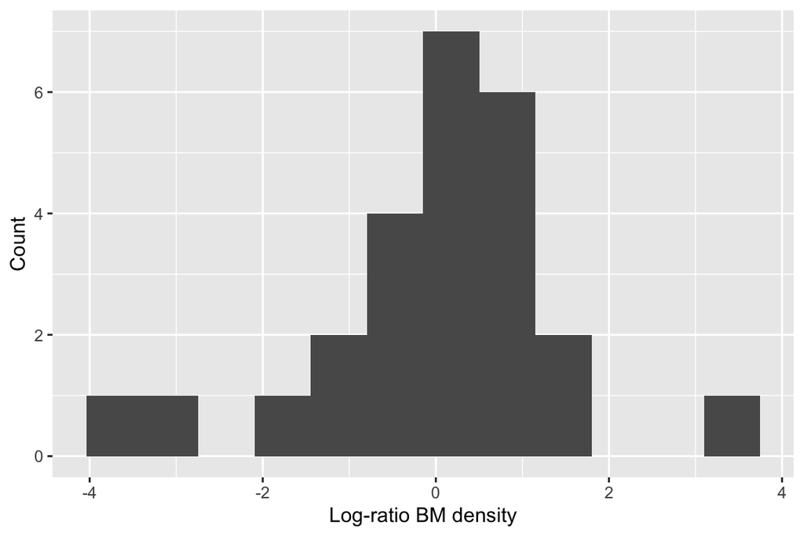

Distribution of log-ratio blue whale density across 25 cruises.

```r
ggplot(whales_ex, aes(x = bm)) +
  geom_histogram(bins = 12) +
  labs(x = "Log-ratio BM density", y = "Count")
```

## Stability selection

The core feature selection method is sparse PLS (sPLS) stability selection (Meinshausen & Bühlmann 2010, adapted for PLS). The idea: fit sPLS across many leave-one-out (LOO) subsamples of the data and a dense hyperparameter grid; features that appear consistently across subsamples are judged “stable.”

### Hyperparameter grid

sPLS has two key hyperparameters: `eta` (sparsity, higher = fewer features selected) and `K` (number of PLS components). We search over a grid covering the interesting range:

```r
eta_vals   <- eta_grid(n = 55)   # 55 values from ~0.4 to ~0.93 on a log scale
ncomp_vals <- 4:12
cat("Grid size:", length(eta_vals), "eta x", length(ncomp_vals),
    "ncomp =", length(eta_vals) * length(ncomp_vals), "combinations\n")
```

```
#> Grid size: 55 eta x 9 ncomp = 495 combinations
```

### Running stability selection

`run_stability_selection()` fits sPLS to each LOO training subset at every (eta, ncomp) combination and tallies how often each ASV is selected. The code below shows the full computation; it takes approximately 3 minutes on the 500-ASV example data and is **not evaluated** here — `sel_freq_bm` is pre-computed and bundled with the package.

```r
partitions <- loo_partitions(whales_ex)

# ~12,375 sPLS fits; ~3 minutes on the 500-ASV example data
sel_freq_bm <- run_stability_selection(
  whales_ex, response = "bm",
  eta_vals   = eta_vals,
  ncomp_vals = ncomp_vals,
  partitions = partitions
)
```

Selection frequencies for a representative hyperparameter configuration (ncomp = 4, eta ≈ 0.7):

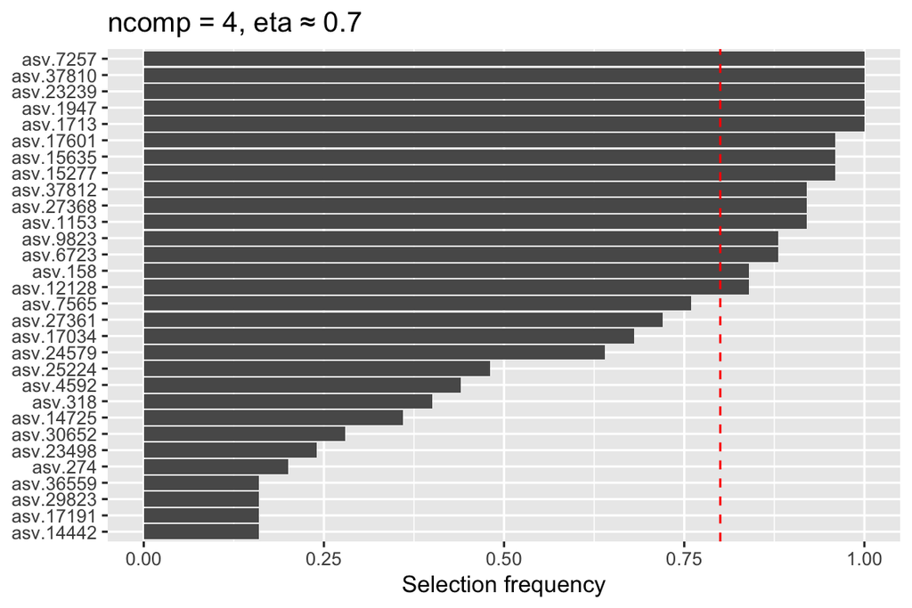

Selection frequencies for the top 30 ASVs at ncomp = 4, eta ≈ 0.7. The dashed red line marks the 0.8 stability threshold.

```r
target_eta <- eta_vals[which.min(abs(eta_vals - 0.7))]

sel_freq_bm |>
  filter(ncomp == 4, eta == target_eta) |>
  slice_max(n, n = 30) |>
  mutate(asv  = fct_reorder(asv, n),
         freq = n / nrow(whales_ex)) |>
  ggplot(aes(x = freq, y = asv)) +
  geom_col() +
  geom_vline(xintercept = 0.8, linetype = "dashed", colour = "red") +
  labs(x = "Selection frequency", y = NULL,
       title = "ncomp = 4, eta \u2248 0.7")
```

### Stable feature sets

`extract_stable_sets()` scans over all eta intervals and identifies configurations where the mean number of selected features satisfies the Meinshausen-Bühlmann false-positive bound. It infers the eta grid and mean selection counts directly from `sel_freq_bm`:

```r
p <- sum(startsWith(names(whales_ex), "asv"))
candidates <- extract_stable_sets(sel_freq_bm, p = p)
candidates |> select(ncomp, eta.min, eta.max, n_stable)
```

```
#> # A tibble: 66 × 4
#>    ncomp eta.min eta.max n_stable
#>    <int>   <dbl>   <dbl>    <int>
#>  1     4   0.592   0.919       36
#>  2     4   0.592   0.925       36
#>  3     4   0.622   0.898       23
#>  4     4   0.622   0.906       23
#>  5     4   0.622   0.913       23
#>  6     4   0.622   0.919       23
#>  7     4   0.622   0.925       23
#>  8     4   0.650   0.881       19
#>  9     4   0.650   0.890       19
#> 10     4   0.650   0.898       19
#> # ℹ 56 more rows
```

The full analysis uses nested cross-validation (`analysis/nested-validation-16s.R`) to select the best-performing candidate. Here we take the most conservative candidate (narrowest eta interval, implying the tightest false-positive control):

```r
best <- candidates |>
  mutate(interval_width = eta.max - eta.min) |>
  slice_min(interval_width, with_ties = FALSE)

stable_asvs <- best$stable_asvs[[1]]
cat("Stable set: ncomp =", best$ncomp,
    " | eta [", round(best$eta.min, 3), ",",
    round(best$eta.max, 3), "]",
    " |", length(stable_asvs), "ASVs\n")
```

```
#> Stable set: ncomp = 4  | eta [ 0.78 , 0.825 ]  | 11 ASVs
```

For reference, `all_stable` contains the 93 ASVs identified as stable for any species in the full 16S analysis. The fraction of the example stable set that is a genuine stable feature:

```r
cat(sum(stable_asvs %in% all_stable), "/", length(stable_asvs),
    "selected ASVs confirmed stable in full analysis\n")
```

```
#> 11 / 11 selected ASVs confirmed stable in full analysis
```

## Model fitting

`fit_pls_stable()` takes the joined data, the response name, the selected ASV names, and the number of components — it handles subsetting and model fitting in one step:

```r
fit_bm <- fit_pls_stable(
  whales_ex, response = "bm",
  stable_asvs = best$stable_asvs[[1]], ncomp = best$ncomp
)
```

PLS component loadings describe the linear combination of ASV abundances most associated with whale density. The regression coefficients summarise each feature’s net contribution after accounting for all components:

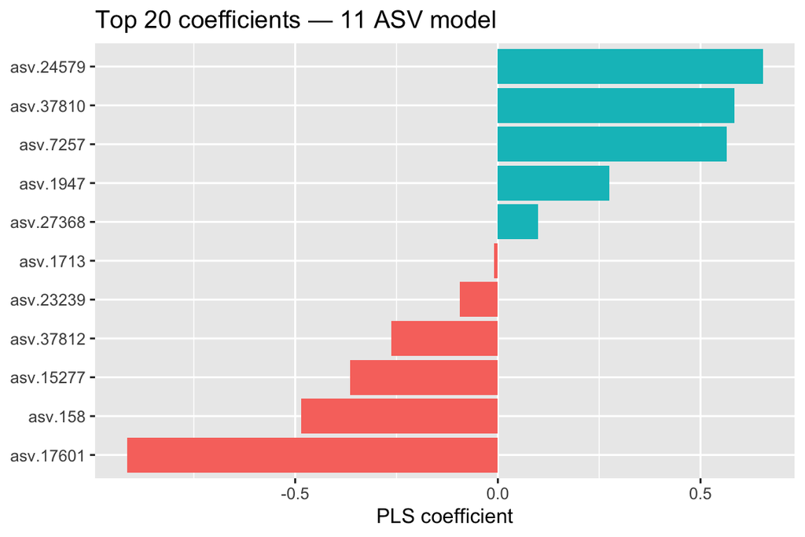

PLS regression coefficients for blue whale density. Positive values indicate ASVs whose abundance increases with blue whale density.

```r
coefs <- coef(fit_bm)[, , paste(best$ncomp, "comps")] |>
  enframe(name = "asv", value = "coef") |>
  mutate(direction = if_else(coef > 0, "positive", "negative"))

coefs |>
  slice_max(abs(coef), n = 20) |>
  mutate(asv = fct_reorder(asv, coef)) |>
  ggplot(aes(x = coef, y = asv, fill = direction)) +
  geom_col(show.legend = FALSE) +
  labs(x = "PLS coefficient", y = NULL,
       title = paste("Top 20 coefficients —", length(stable_asvs), "ASV model"))
```

### Model metrics

Fitted values on the log-ratio scale and back-transformed predictions on the original density scale:

```r
lr_obs <- whales_ex$bm
lr_fit <- fitted(fit_bm)[, , paste(best$ncomp, "comps")]

# Back-transform: dens = exp(lr.fit + log(seasonal_mean_density))
dens_means_long <- dens_means |>
  pivot_longer(-season, names_to = "species", values_to = "seasonal.mean") |>
  mutate(species = str_remove(species, "log\\.") |> str_remove("\\.imp\\.mean"))

fit_df <- tibble(cruise = whales_ex$cruise, lr.obs = lr_obs, lr.fit = lr_fit) |>
  left_join(dens_raw |> filter(species == "bm") |>
              select(cruise, season, dens.obs = estimate),
            by = "cruise") |>
  left_join(filter(dens_means_long, species == "bm"), by = "season") |>
  mutate(dens.fit   = exp(lr.fit + seasonal.mean),
         lr.resid   = lr.obs - lr.fit,
         dens.resid = dens.obs - dens.fit)

n_obs  <- nrow(fit_df)
ncomp  <- best$ncomp
adj_rsq_lr   <- 1 - ((n_obs - 1) / (n_obs - ncomp - 1)) *
                    var(fit_df$lr.resid)   / var(fit_df$lr.obs)
adj_rsq_dens <- 1 - ((n_obs - 1) / (n_obs - ncomp - 1)) *
                    var(fit_df$dens.resid) / var(fit_df$dens.obs)

cat(sprintf("Adjusted R\u00b2 (log-ratio scale):  %.3f\n", adj_rsq_lr))
```

```
#> Adjusted R² (log-ratio scale):  0.851
```

```r
cat(sprintf("Adjusted R\u00b2 (density scale):    %.3f\n", adj_rsq_dens))
```

```
#> Adjusted R² (density scale):    0.705
```

These figures reflect in-sample fit on all 25 observations; the full analysis reports out-of-sample RMSPE via LOO cross-validation (see `vignette("full-analysis")`).

### Predictions vs. observed

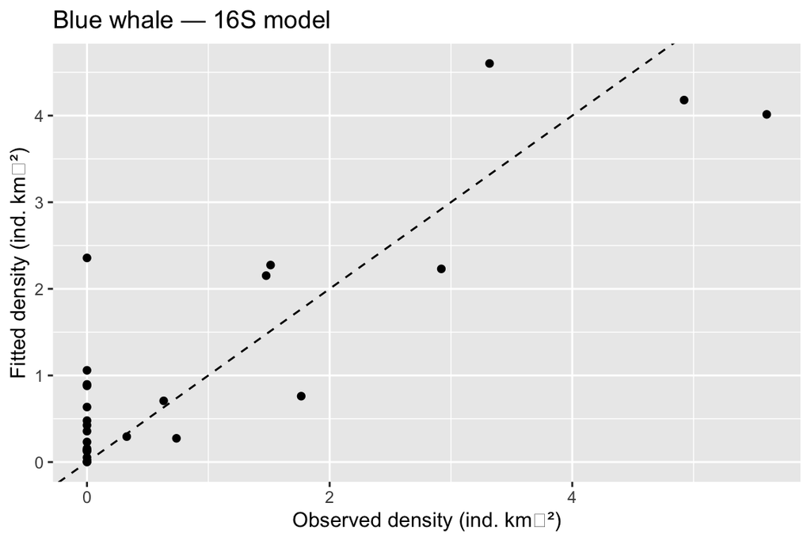

PLS model fitted values vs. observed blue whale density (individuals km⁻²). Points represent individual CalCOFI cruises; the dashed line is the 1:1 reference.

```r
fit_df |>
  ggplot(aes(x = dens.obs, y = dens.fit)) +
  geom_point() +
  geom_abline(linetype = "dashed") +
  labs(x = "Observed density (ind. km\u207b\u00b2)",
       y = "Fitted density (ind. km\u207b\u00b2)",
       title = "Blue whale — 16S model")
```

## References

Meinshausen, N., & Bühlmann, P. (2010). Stability selection. *Journal of the Royal Statistical Society: Series B*, 72(4), 417–473.